# Task1-upload

## MHD Project (in z)

We have to solve for $B_r$ and $B_{\phi}$ in z.(neglect the r derivatives and $\alpha$ term in the induction equation) I'm using the unitless equation which we findout in Assignment-3 Induction equation is following $$\frac{\partial B_r}{\partial t}=-\frac{V_r}{r}\frac{\partial }{\partial r}(r*B_r)+\frac{\partial }{\partial z}(V_z*B_r)-\frac{\partial }{\partial z}(\alpha*B_{\phi})+\frac{\partial }{\partial r}(\frac{\partial }{r \partial r}(r B_{\phi}))+\frac{\partial^2 B_r}{\partial z ^2}$$ $$\frac{\partial B_{\phi}}{\partial t}=-q\Omega B_r-\frac{\partial }{\partial r}(V_r*B_{\phi})+\frac{\partial }{\partial z}(V_z*B_{\phi})-\frac{\partial }{\partial z}(\alpha*B_r)+\frac{\partial }{\partial r}(\frac{\partial }{r \partial r}(r B_{\phi}))+\frac{\partial^2 B_r}{\partial z ^2}$$ Now the equation consider for the task one is (Only in z derivatives are consider and Velocity ,$\alpha$ term are not taken) $$\frac{\partial B_r}{\partial t}=\frac{\partial^2 B_r}{\partial z ^2}$$ $$\frac{\partial B_{\phi}}{\partial t}=\frac{\partial^2 B_{\phi}}{\partial z ^2}$$ For Numerical calulation i used the second order finite difference to find out the spatial derivatives and i use Range kutta to evolve in time. Since this is partial differential equation, I can use RK method such that the z evolving in time is zero. Therefore i calculated the spatial derivatives at some fixed points (z) at a time and integrate using RK method at dt time to get the magnetic field at that time.Then again for next dt time,i calculated the spatial derivatives for the changed magnetic field after previous step for all z and again continous the time stepping.Now in between the each time stepping, i reset the boundary condition value for magnetic field values(if its some how its changed while time evolving or as function (in general)).From this we can calulate the magnetic field changes as function z as well as the function of time t.

Fintie difference method used for finding the spatial derivates (any other function or spatial derivates need) and evolve in RK4 time steeping to ingrate to find out the required magnetic fields at each points.

```python
# importing the required libraries
import math
import numpy as np
import matplotlib.pyplot as plt
from tqdm import tqdm
```

```python
# spatial derivative function using finite difference method

def ddBrdz(B,dz,Nz):
    Br = np.zeros((Nz))
    for i in range(1,Nz-2):
        #Br[i]=(-B[i-2,0]+16*B[i-1,0]-30*B[i,0]+16*B[i+1,0]-B[i+2,0])/(12*dz*dz)
        Br[i]=(B[i-1,0]+(-2*B[i,0])+B[i+1,0])/(dz*dz)
    i=0
    Br[i]=((2*B[i,0])-(5*B[i+1,0])+(4*B[i+2,0])-B[i+3,0])/(dz*dz)
    i=Nz-1
    Br[i]=((2*B[i,0])-(5*B[i-1,0])+(4*B[i-2,0])-B[i-3,0])/(dz*dz)
    #print(B)
    return Br
def dBrdz(B,dz,Nz):
    Br = np.zeros((Nz))

    for i in range(1,Nz-2):
        Br[i]=(B[i+1,0]-B[i-1,0])/(2*dz)
    i=0
    Br[i]=(4*B[i+1,0]-B[i+2,0]-3*B[i,0])/(2*dz)
    i=Nz-1
    Br[i]=(-4*B[i-1,0]+B[i-2,0]+3*B[i,0])/(2*dz)
    return Br

def ddBphidz(B,dz,Nz):
    Bphi = np.zeros((Nz))
    for i in range(1,Nz-2):
        #Bphi[i]=(-B[i-2,1]+16*B[i-1,1]-30*B[i,1]+16*B[i+1,1]-B[i+2,1])/(12*dz*dz)
        Bphi[i]=(B[i-1,1]+(-2*B[i,1])+B[i+1,1])/(dz*dz)
    i=0
    Bphi[i]=((2*B[i,1])-(5*B[i+1,1])+(4*B[i+2,1])-B[i+3,1])/(dz*dz)
    i=Nz-1
    Bphi[i]=((2*B[i,1])-(5*B[i-1,1])+(4*B[i-2,1])-B[i-3,1])/(dz*dz)
    return Bphi

def dBphidz(B,dz,Nz):
    Bphi = np.zeros((Nz))
    for i in range(1,Nz-2):
        Bphi[i]=(B[i+1,1]-B[i-1,1])/(2*dz)
    i=0
    Bphi[i]=(4*B[i+1,1]-B[i+2,1]-3*B[i,1])/(2*dz)
    i=Nz-1
    Bphi[i]=(-4*B[i-1,1]+B[i-2,1]+3*B[i,1])/(2*dz)
    return Bphi
```

```python
# dB_r/dt=f1()
# dB_phi/dt=f2()
def f1(B,dz,Nz):
    return ddBrdz(B,dz,Nz)
    #return np.gradient(B, axis = 0)
def f2(B,dz,Nz):
    return ddBphidz(B,dz,Nz)
    #return np.gradient(np.gradient(B, axis = 0), axis = 1)
```

```python
#We use the unitless calculations
z_i = 0.0  # start of spatial region in z
z_f = 2.0  # end of spatial domain in z
T = 1.0  # Total simulation time with respect to t_f
Nz = 101  # Number of spatial grid points
Nt = 10000  # Number of time steps
dz = (z_f - z_i) / (Nz - 1)  # Spatial step size
dt = T / Nt  # Time step size


# creating the mesh of z (discetizing the z axis within our region with each distance as dx)
z = np.linspace(z_i, z_f, Nz)
t = np.linspace(0, T, Nt+1)
# Now creating the B array with first component is z position value and second compenent is defingin the r (0),phi(1) and intial we make this zero array values
```

# Case 1,we use the boundary condition and Intial values as follows

```python
# Now applying the Intial values for the B_r0 and B_phi0

def B_phi0(r, phi, z):
    return (np.sin((np.pi * z) / 2.0))

def B_r0(r, phi, z):
    return (np.sin((np.pi * z) / 2.0) +np.sin((np.pi * z)))+1/2*np.sin(4*(np.pi * z))

#Boundary condition
a=0  #B_r at Z=Z_i
b=0  #B_r at Z=Z_f
c=0  #B_phi at Z=Z_i
d=0  #B_phi at Z=Z_f

B = np.zeros((Nz, 2))
# B_r- intial values are
B[:, 0] = B_r0(0, 0, z)
# B_phi- intial values are
B[:, 1] = B_phi0(0,0,z)
# print(B)

# Create arrays to store the solution in time
iterations_to_save=[0,60,600,Nt/8,Nt/4,Nt/2,Nt]
B_list= []
B_time = np.zeros((Nt+1, 1))
#B_pitch = np.zeros((Nt+1, 1))
B_pitch=[]

if 0 in iterations_to_save:
    B_list.append(np.copy(B))
```

```python
for n in tqdm(range(1, Nt + 1)):
    #dBrdz=dBrdz(B,dz,Nz)
    #dBphidz=dBphidz(B,dz,Nz)
    #ddBrdz2=dBrdz(dBrdz,dz,Nz)
    #Now using Runge-Kutta 4th order integration for B_r in time at z
    #dBrdt = np.zeros((Nz, 2))
    #dBrdt=f1(B,dz,Nz)
    k1 = f1(B,dz,Nz)
    k2 = f1(B,dz,Nz)
    k3 = (f1(B,dz,Nz))
    k4 = (f1(B,dz,Nz))
    B[:, 0] = B[:, 0] + ((dt / 6.0) * (k1 +( 2 * k2) + (2 * k3) + k4))
    # Runge-Kutta 4th order integration for B_phi in time at  fixed z
    k1 = (f2(B,dz,Nz))
    k2 = (f2(B,dz,Nz))
    k3 = (f2(B,dz,Nz))
    k4 = (f2(B,dz,Nz))
    B[:, 1] = B[:, 1] + ((dt / 6.0) * (k1 + (2 * k2) + (2 * k3) + k4))

    #fixed point(like middle point)
    # B_time[(n-1)]=np.log10(B[50,0])
    B_time[(n-1)]=np.log10(np.sqrt((B[50,0])**2+(B[50,1])**2))
    #B_pitch[(n-1)]= np.arctan(B[50,1]/B[50,0])

    B[0,1]=c
    B[Nz-1,0]=b
    B[0,0]=a
    B[Nz-1,1]=d

    if n in iterations_to_save:
        B_list.append(np.copy(B))
        B_pitch.append(np.copy(B))
```

# Case-2, we use the boundary condition and Intial values as follows

```python
# Now applying the Intial values for the B_r0 and B_phi0

def B_phi0(r, phi, z):
    return (np.exp(z))

def B_r0(r, phi, z):
    return (np.cos((2* z)))

#Boundary condition
a=1  #B_r at Z=Z_i
b=np.cos(4) #B_r at Z=Z_f
c=1  #B_phi at Z=Z_i
d=np.exp(2)  #B_phi at Z=Z_f

B = np.zeros((Nz, 2))
# B_r- intial values are
B[:, 0] = B_r0(0, 0, z)
# B_phi- intial values are
B[:, 1] = B_phi0(0,0,z)
# print(B)

# Create arrays to store the solution in time
iterations_to_save=[0,60,600,Nt/8,Nt/4,Nt/2,Nt]
B_list_2= []
B_time_2 = np.zeros((Nt+1, 1))
#B_pitch = np.zeros((Nt+1, 1))
B_pitch_2=[]

if 0 in iterations_to_save:
    B_list_2.append(np.copy(B))
```

```python
for n in tqdm(range(1, Nt + 1)):
    #dBrdz=dBrdz(B,dz,Nz)
    #dBphidz=dBphidz(B,dz,Nz)
    #ddBrdz2=dBrdz(dBrdz,dz,Nz)
    #Now using Runge-Kutta 4th order integration for B_r in time at z
    #dBrdt = np.zeros((Nz, 2))
    #dBrdt=f1(B,dz,Nz)
    k1 = f1(B,dz,Nz)
    k2 = f1(B,dz,Nz)
    k3 = (f1(B,dz,Nz))
    k4 = (f1(B,dz,Nz))
    B[:, 0] = B[:, 0] + ((dt / 6.0) * (k1 +( 2 * k2) + (2 * k3) + k4))
    # Runge-Kutta 4th order integration for B_phi in time at  fixed z
    k1 = (f2(B,dz,Nz))
    k2 = (f2(B,dz,Nz))
    k3 = (f2(B,dz,Nz))
    k4 = (f2(B,dz,Nz))
    B[:, 1] = B[:, 1] + ((dt / 6.0) * (k1 + (2 * k2) + (2 * k3) + k4))

    #fixed point(like middle point)
    # B_time[(n-1)]=np.log10(B[50,0])
    B_time_2[(n-1)]=np.log10(np.sqrt((B[50,0])**2+(B[50,1])**2))
    #B_pitch[(n-1)]= np.arctan(B[50,1]/B[50,0])

    B[0,1]=c
    B[Nz-1,0]=b
    B[0,0]=a
    B[Nz-1,1]=d

    if n in iterations_to_save:
        B_list_2.append(np.copy(B))
        B_pitch_2.append(np.copy(B))
```

# plotting the results for the above

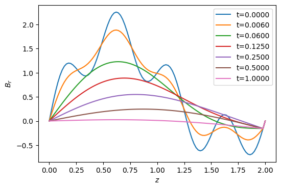

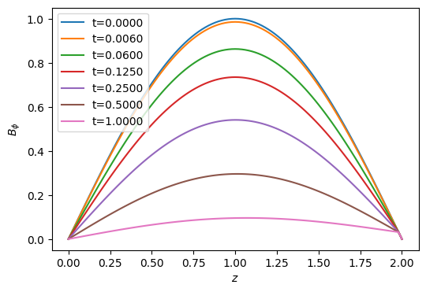

```
The Decay rate is [-2.72989517]
```

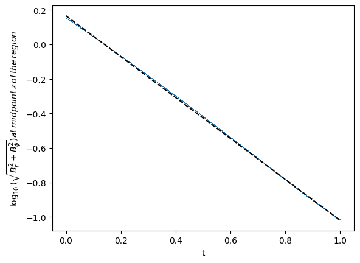

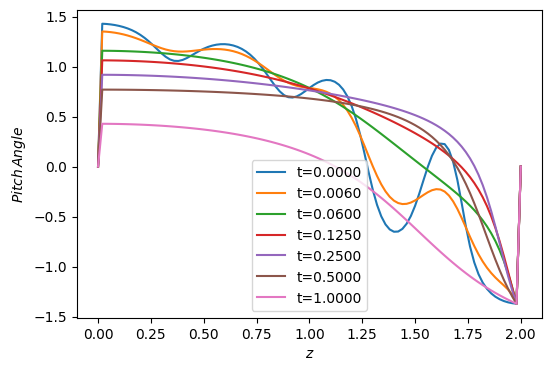

```python
# plotting the results of example one
fig, ax = plt.subplots(1, 1, figsize=(6, 4))
for iteration in range(len(iterations_to_save)):
    ax.plot(z, B_list[iteration][:, 0], label=f't={iterations_to_save[iteration] * dt:.4f}')
ax.set_xlabel(r'$z$')
ax.set_ylabel(r'$B_r$')
ax.legend()
plt.show()

fig, ax = plt.subplots(1, 1, figsize=(6, 4))
for iteration in range(len(iterations_to_save)):
    ax.plot(z,B_list[iteration][:, 1], label=f't={iterations_to_save[iteration] * dt:.4f}')
ax.set_xlabel(r'$z$')
ax.set_ylabel(r'$B_{\phi}$')
ax.legend()
plt.show()


m, b = np.polyfit(t, B_time, 1)
print("The Decay rate is",m*np.log(10))
plt.plot(t, B_time, ',', t, m*t+b, '--k')
plt.xlabel('t')
plt.ylabel(r'$\log_{10}(\sqrt{B_r^2+B_{\phi}^2}) at\, midpoint\, z\, of\,the\, region$')
plt.show()

B_pitch = np.zeros((Nz, len(iterations_to_save)))
for iteration in range(len(iterations_to_save)):
    for i in range(1,Nz-1):
        B_pitch[i,iteration]=np.arctan(B_list[iteration][i, 0]/B_list[iteration][i, 1])

fig, ax = plt.subplots(1, 1, figsize=(6, 4))
for iteration in range(len(iterations_to_save)):
    ax.plot(z, B_pitch[:,iteration], label=f't={iterations_to_save[iteration] * dt:.4f}')
ax.set_xlabel(r'$z$')
ax.set_ylabel(r'$Pitch\, Angle$')
ax.legend()
plt.show()


# plt.plot(t, B_pitch, t, m*t+b, '--k')
# plt.xlabel('t')
# plt.ylabel(r'$\log_{10}(\sqrt{B_r^2+B_{\phi}^2}) at\, midpoint\, Z\, of\, region$')
# plt.show()
```

# Plotting the results of case-2 for Seed field and Boundary condition

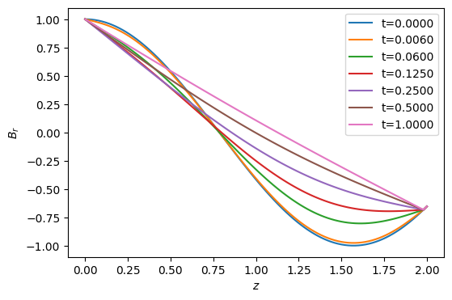

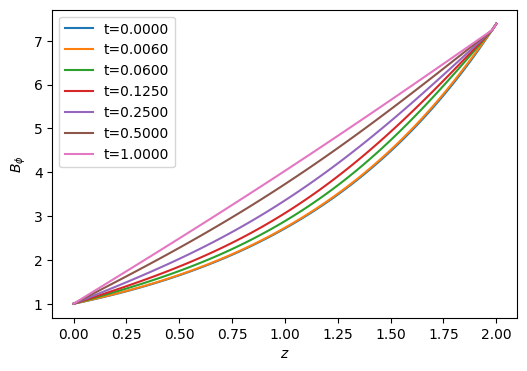

```python
# plotting the results of example one
fig, ax = plt.subplots(1, 1, figsize=(6, 4))
for iteration in range(len(iterations_to_save)):
    ax.plot(z, B_list_2[iteration][:, 0], label=f't={iterations_to_save[iteration] * dt:.4f}')
ax.set_xlabel(r'$z$')
ax.set_ylabel(r'$B_r$')
ax.legend()
plt.show()

fig, ax = plt.subplots(1, 1, figsize=(6, 4))
for iteration in range(len(iterations_to_save)):
    ax.plot(z,B_list_2[iteration][:, 1], label=f't={iterations_to_save[iteration] * dt:.4f}')
ax.set_xlabel(r'$z$')
ax.set_ylabel(r'$B_{\phi}$')
ax.legend()
plt.show()


# m, b = np.polyfit(t, B_time_2, 1)
# print("The Decay rate is",m*np.log(10))
# plt.plot(t, B_time_2, ',', t, m*t+b, '--k')
# plt.xlabel('t')
# plt.ylabel(r'$\log_{10}(\sqrt{B_r^2+B_{\phi}^2}) at\, midpoint\, z\, of\,the\, region$')
# plt.show()

# B_pitch = np.zeros((Nz, len(iterations_to_save)))
# for iteration in range(len(iterations_to_save)):
#     for i in range(1,Nz-1):
#         B_pitch_2[i,iteration]=np.arctan(B_list_2[iteration][i, 0]/B_list_2[iteration][i, 1])

# fig, ax = plt.subplots(1, 1, figsize=(6, 4))
# for iteration in range(len(iterations_to_save)):
#     ax.plot(z, B_pitch_2[:,iteration], label=f't={iterations_to_save[iteration] * dt:.4f}')
# ax.set_xlabel(r'$z$')
# ax.set_ylabel(r'$Pitch\, Angle$')
# ax.legend()
# plt.show()


# plt.plot(t, B_pitch_2, t, m*t+b, '--k')
# plt.xlabel('t')
# plt.ylabel(r'$\log_{10}(\sqrt{B_r^2+B_{\phi}^2}) at\, midpoint\, Z\, of\, region$')
# plt.show()
```

From the case 1 and 2, we could see that the Magnetic fields evolve to straight line function between the intial boundary point and final boundary point after some time whatever the seed function we give for them intially.Its only depends on the boundary points.

For the case-1 and case-2, we could see that whatever is the intial seed magnetic field (for a fixed Boundary Condition) all of Magnetic field evolve to a same function as its straight line from intial boundary point to final boundary point.Now we could also see the Decay rate of case-1 magnetic field to be -2.72989517 with 0 as boundary condition values.